# Visitas de clientes a varejista

## Parte I

Esse documento tem como objetivo mostrar uma análise de dados realizada no conjunto base **Testedata**, que registra as visitas de clientes a um determinado varejista.

O banco consiste de 7 colunas sendo elas:

1. **user** - identificador do usuario que visitou a loja
2. **laitutde** - coordenada geográfica da loja
3. **longitude** - coordenada geográfica da loja
4. **date** - data da visita a loja
5. **day_of_week** - dia da visita a loja
6. **hour** - hora da visita a loja
7. **categoria** - tipo de loja da visita

Os dados de visitas dos clientes podem direcionar o negocio, trazendo informacoes a respeito do comportamento dos clientes de cada setor comercial, de acordo com seus horarios de visitas. As informacoes colhidas desses dados podem auxiliar, por exemplo, no planejamento e monitoramento diario das lojas.

## Preparação

Para iniciar a análise, vamos importar as bibliotecas necessárias, carregar os dados e verificar quais os tipos de dados em cada coluna, alem de verificar algumas propriedades estatísticas.

```python
# imports de bibliotecas
import pandas as pd
import numpy as np
import time
import seaborn as sns
import matplotlib.pyplot as plt
%matplotlib inline
import warnings
warnings.filterwarnings('ignore')
```

```python
# carregamento dos dados
data = pd.read_csv('Testedata.csv')
data.head()
```

|  | user | latitude | longitude | date | day_of_week | hour | categoria |
| --- | --- | --- | --- | --- | --- | --- | --- |
| 0 | User_3401 | -26.489503 | -49.028018 | 2018-07-08 | Saturday | 18 | bakery |
| 1 | User_539 | -14.457400 | -46.433148 | 2018-07-08 | Sunday | 7 | restaurant |
| 2 | User_789 | -8.903859 | -36.487485 | 2018-07-08 | Saturday | 9 | night_club |
| 3 | User_2814 | -22.823960 | -43.012243 | 2018-07-08 | Saturday | 22 | store |
| 4 | User_3432 | -24.949576 | -53.488507 | 2018-07-08 | Sunday | 3 | restaurant |

Carregando corretamente os dados e visualizando os 5 primeiros registros, conseguimos perceber uma inconsistência entre as colunas **date** e **day_of_week**, mais precisamente nos dois primeiros registros. A coluna date no registro 0 tem o valor **2018-07-08** e a coluna day_of_week tem o valor **Sturday**, enquanto no registro 1 a coluna date tem o memsmo valor do registro anterior, porem a coluna day_of_week tem o valor **Sunday**. Dado que os dois registros tem valores da coluna date iguais, e impossivel serem dias da semana diferentes. Vamos corrigir utilizando as propriedades de data e hora do pandas, mas antes vamos verificar os tipos dos dados:

```python
data.info()
```

```
<class 'pandas.core.frame.DataFrame'>
RangeIndex: 30802 entries, 0 to 30801
Data columns (total 7 columns):
user           30802 non-null object
latitude       30802 non-null float64
longitude      30802 non-null float64
date           30802 non-null object
day_of_week    30802 non-null object
hour           30802 non-null int64
categoria      30802 non-null object
dtypes: float64(2), int64(1), object(4)
memory usage: 1.6+ MB
```

Precisamos entao converter os dados da coluna **date** para o tipo **datetime** e substituir os valores da coluna **day_of_week** com os valores corretos gerados pela funcao **day_name()**:

```python
data['date'] = pd.to_datetime(data['date'])
data['day_of_week'] = data['date'].dt.day_name()
data.head()
```

|  | user | latitude | longitude | date | day_of_week | hour | categoria |
| --- | --- | --- | --- | --- | --- | --- | --- |
| 0 | User_3401 | -26.489503 | -49.028018 | 2018-07-08 | Sunday | 18 | bakery |
| 1 | User_539 | -14.457400 | -46.433148 | 2018-07-08 | Sunday | 7 | restaurant |
| 2 | User_789 | -8.903859 | -36.487485 | 2018-07-08 | Sunday | 9 | night_club |
| 3 | User_2814 | -22.823960 | -43.012243 | 2018-07-08 | Sunday | 22 | store |
| 4 | User_3432 | -24.949576 | -53.488507 | 2018-07-08 | Sunday | 3 | restaurant |

Inconsistência corrigida, vamos verificar se existem valores nulos na base:

```python
data.isnull().values.any()
```

```
False
```

A base nao possui valores nulos!

Vamos verificar algumas propriedades estatísticas dos dados numericos da base:

```python
data.describe()
```

|  | latitude | longitude | hour |
| --- | --- | --- | --- |
| count | 30802.000000 | 30802.000000 | 30802.000000 |
| mean | -17.919721 | -45.286508 | 13.507597 |
| std | 7.799343 | 5.808439 | 5.162345 |
| min | -33.692640 | -72.674253 | 0.000000 |
| 25% | -23.512122 | -48.460235 | 10.000000 |
| 50% | -21.123770 | -46.516913 | 13.000000 |
| 75% | -12.188372 | -42.004125 | 18.000000 |
| max | 4.478833 | -32.428413 | 23.000000 |

Interpretando melhor os dados estatisticos:

- As visitas ocorrem em média por volta das 13hs
- 25% das visitas ocorrem até às 10hs
- 50% das visitas ocorrem até às 13hs
- 75% das visitas ocorrem até às 18hs

## Análise

Depois de realizar algumas transformações nos dados e verificar suas propriedades, vamos propor algumas perguntas que podem ser respondidas através da análise dos dados e mostrar como elas podem gerar valor para o varejista. As perguntas serao:

1. Em quais regiões a maior parte das visitas está concentrada?
2. Qual a hora, o dia da semana e o tipo de loja mais visitado em parte da região nordeste?
3. Qual é a média de visitas por dia e hora aos estabelecimentos de cada categoria?
4. Quais são as três categorias mais visitadas e as três menos visitadas durante cada turno do dia?
5. Em quais regiões devem ser abertos novos restaurantes, de acordo com o dia da semana e a hora que eles serao visitados?

Ao final das análises e resposta de cada uma dessas perguntas, vamos analisar outras questẽes que tambem podem ser de interesse do varejista.

### 1) Em quais regiões a maior parte das visitas está concentrada?

Para responder essa pergunta, vamos plotar um gráfico, com a biblioteca seaborn, utilizando a latitude e longitude das visitas e dessa forma observar a concentração.

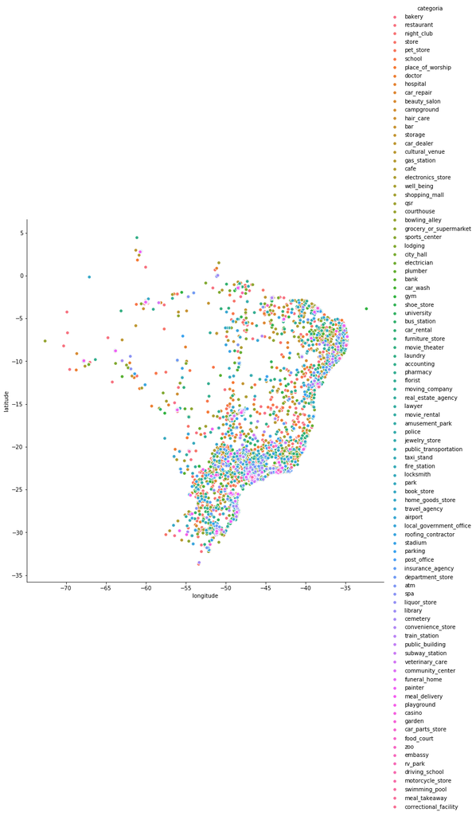

```python
sns.pairplot(x_vars=['longitude'], y_vars=['latitude'], data=data, hue="categoria", size=10)
plt.show()
```

De acordo com o mapa plotado, fica claro que a maior parte das visitas se da no entorno da costa brasileira, sendo mais concentradas no litoral do Nordeste e da regiao Sudeste, estando muito concentradas também no estado de Sao Paulo.

Essa informação pode ser relevante caso o varejista deseje abrir novas lojas de uma categoria específica. Além disso, pode ajudar na forma de distribuição dos produtos de cada loja a depender da sua localidade.

### 2) Qual a hora, o dia da semana e o tipo de loja mais visitado em parte da região nordeste?

Para responder essa pergunta, vamos analisar a faixa da regiao Nordeste que se extende da latitude -15 ate a -3 e da longitude -43 ate a -30.

```python
region = data[(data['longitude'].between(-43, -30))  & (data['latitude'].between(-15, -3))]

category_per_visit = region.groupby(['categoria', 'hour', 'day_of_week'])['user'].count()
category_per_visit.loc[category_per_visit == category_per_visit.max()]
```

```
categoria   hour  day_of_week
restaurant  8     Sunday         21
            13    Friday         21
Name: user, dtype: int64
```

O tipo de loja mais visitada na faixa da regiao nordeste que se da entre as latitudes e longitudes citadas é **restaturante**. Além disso, eles são mais frequentados nos domingos às 8hs e nas sextas às 13hs.

Essa informacao é relevante, pois informa um negocio que pode ser rentável ao varejista devido a quantidade de vistias daquela categoria. Também mostra que nos horários e dias da semana encontrados, o varejista deve dar mais atenção ao estoque de comidas e bebidas, pois o movimento é maior que nos outros.

### 3) Qual é a media de visitas por hora, nos dias da semana, aos estabelecimentos de cada categoria?

A resposta para essa pergunta vem a partir da média da quantidade de visitas, quando agrupamos os dados de acordo com os dias da semana, hora e categoria.

```python
for cat in data['categoria'].unique():
    print("Categoria - {}: ".format(cat))
    for day in data['day_of_week'].unique():
        cat_day = data[(data['day_of_week'] == day) & (data['categoria'] == cat)]
        mean_cat_hour_day = cat_day.groupby(['categoria', 'day_of_week','hour'])['user'].count().mean()

        if not(np.isnan(mean_cat_hour_day)):
            print("{}: {:.2f} visitas por hora.".format(day, mean_cat_hour_day))
    print('\n')
```

```
Categoria - bakery:
Sunday: 4.86 visitas por hora.
Tuesday: 4.90 visitas por hora.
Monday: 4.10 visitas por hora.
Wednesday: 3.91 visitas por hora.
Thursday: 5.16 visitas por hora.
Saturday: 4.50 visitas por hora.
Friday: 4.13 visitas por hora.


Categoria - restaurant:
Sunday: 37.00 visitas por hora.
Tuesday: 34.38 visitas por hora.
Monday: 30.62 visitas por hora.
Wednesday: 34.62 visitas por hora.
Thursday: 38.33 visitas por hora.
Saturday: 33.17 visitas por hora.
Friday: 34.62 visitas por hora.


Categoria - night_club:
Sunday: 1.81 visitas por hora.
Tuesday: 1.92 visitas por hora.
Monday: 1.42 visitas por hora.
Wednesday: 1.69 visitas por hora.
Thursday: 1.47 visitas por hora.
Saturday: 1.36 visitas por hora.
Friday: 1.45 visitas por hora.


Categoria - store:
Sunday: 20.54 visitas por hora.
Tuesday: 19.17 visitas por hora.
Monday: 19.08 visitas por hora.
Wednesday: 21.25 visitas por hora.
Thursday: 23.83 visitas por hora.
Saturday: 20.46 visitas por hora.
Friday: 20.88 visitas por hora.


```

[output cut: 811 more lines]

```

Categoria - swimming_pool:
Sunday: 1.00 visitas por hora.
Tuesday: 1.00 visitas por hora.
Monday: 1.00 visitas por hora.
Thursday: 1.00 visitas por hora.


Categoria - meal_takeaway:
Monday: 1.00 visitas por hora.


Categoria - correctional_facility:
Sunday: 1.00 visitas por hora.
Friday: 1.00 visitas por hora.
```

Dado que o varejista possui essa informação, ele consegue ter uma visibilidade de como se comportam as visitas por hora em cada tipo de estabelecimento e dessa forma pode priorizar algum tipo de promoção, nos dias que ele possui menor numero de visitas por hora, para angariar novas visitas.

### 4) Quais são as três categorias mais visitadas e as três menos visitadas durante cada turno do dia?

Para responder essa pergunta, precisamos dividir os turnos de acordo com as horas do dia. Os turnos serão:

- Madrugada (0): das 0h às 4:59hs
- Manhã (1): das 5hs às 11:59hs
- Tarde (2): das 12hs às 16:59hs
- Noite (3): das 17hs às 23:59hs

```python
# criar coluna turno de acordo com a hora:  0 - madrugada; 1 - manhã; 2 - tarde; 3 - noite;
def create_shift(hour):
    if (hour >= 0) and (hour < 5):
        return 0
    elif (hour >= 5) and (hour < 12):
        return 1
    elif (hour >= 12) and (hour < 17):
        return 2
    else:
        return 3

data['turno'] = data.apply(lambda x: create_shift(x['hour']), axis=1)
```

A criação de novas colunas a partir das colunas já existentes, pode nos trazer mais informações.

```python
group_turno_category = data.groupby(['turno', 'categoria'])['user'].count()

print('Categorias mais visitadas por turno: \n')
for shift in range(0, 4):
    print('Para o turno {} temos:'.format(shift))
    print(group_turno_category[shift].nlargest(n=3))
    print('\n')

print('Categorias menos visitadas por turno: \n')
for shift in range(0, 4):
    print('Para o turno {} temos:'.format(shift))
    print(group_turno_category[shift].nsmallest(n=3))
    print('\n')
```

```
Categorias mais visitadas por turno:

Para o turno 0 temos:
categoria
restaurant    250
store         156
school         72
Name: user, dtype: int64


Para o turno 1 temos:
categoria
restaurant    1770
store         1024
school         542
Name: user, dtype: int64


Para o turno 2 temos:
categoria
restaurant    1910
store         1221
school         590
Name: user, dtype: int64


Para o turno 3 temos:
categoria
restaurant    1896
store         1060
school         524
Name: user, dtype: int64


Categorias menos visitadas por turno:

Para o turno 0 temos:
categoria
campground       1
movie_theater    1
```

[output cut: 11 more lines]

```

Para o turno 2 temos:
categoria
car_parts_store          1
community_center         1
correctional_facility    1
Name: user, dtype: int64


Para o turno 3 temos:
categoria
embassy          1
food_court       1
meal_delivery    1
Name: user, dtype: int64
```

Essa informação é relevante, pois o varejista pode monitorar o comportamento das visitas a cada categoria dessas em cada turno e dessa forma dedicar mais ou menos funcionários ou equipamentos para aquela loja.

### 5) Em quais regiões devem ser abertos novos restaurantes, de acordo com o dia da semana e o turno que eles serão visitados?

Para responder essa pergunta podemos fazer algum tipo de clusterização e assim definir em quantos grupos podemos dividir os nossos dados da categoria restaurante de acordo com latitude, longitude, dia da semana e turno que eles são visitados. Podemos utilizar o modelo de **clusterização KMeans** que se comporta bem com latitude e longitude.

Primeiro vamos transformar os dados categoricos que precisamos para o KMeans em dados numéricos e fazer isso sobre uma cópia dos dados para não alterá-los definitivamente.

```python
data_cp = data.copy()

# trocando as strings por numero
data_cp['categoria'] = pd.Categorical(data_cp['categoria'])
data_cp['categoria'] = data_cp['categoria'].cat.codes

data_cp['date'] = pd.to_datetime(data_cp['date'])
data_cp['day_of_week'] = data_cp['date'].dt.weekday

data_cp = data_cp.drop(['user', 'date', 'hour'], axis=1)

data_cp.head()
```

|  | latitude | longitude | day_of_week | categoria | turno |
| --- | --- | --- | --- | --- | --- |
| 0 | -26.489503 | -49.028018 | 6 | 4 | 3 |
| 1 | -14.457400 | -46.433148 | 6 | 74 | 1 |
| 2 | -8.903859 | -36.487485 | 6 | 59 | 1 |
| 3 | -22.823960 | -43.012243 | 6 | 84 | 3 |
| 4 | -24.949576 | -53.488507 | 6 | 74 | 0 |

Após essa conversão, os **restaurantes** agora são representados pelo número **74**. Vamos montar e treinar o **KMeans** com os novos dados.

Para avaliar a eficiência de um clustering podemos utilizar o coeficiente de silhueta de cada ponto dos dados. O coeficiente de silhueta para um ponto de dado mede quão similar ele é do seu cluster atribuído, de -1 (não similar) a 1 (similar).

```python
from sklearn.cluster import KMeans
from sklearn.metrics import silhouette_score

random_state = 42

# com a conversão, a categoria restaurante ficou com o código 74
restaurant = data_cp[data_cp['categoria'] == 74]

# testando de 2 a 20 clusters
for i in range(2, 21):
    clusterer = KMeans(n_clusters=i, random_state=random_state)
    clusterer.fit(restaurant)

    preds = clusterer.predict(restaurant)

    centers = clusterer.cluster_centers_

    score = silhouette_score(restaurant, clusterer.labels_, random_state=random_state)
    print("Para k = {0} o score é: {1}".format(i, score))
```

```
Para k = 2 o score é: 0.5787325025231472
Para k = 3 o score é: 0.609011843886863
Para k = 4 o score é: 0.4226318219977715
Para k = 5 o score é: 0.44088404524241953
Para k = 6 o score é: 0.4300653566839961
Para k = 7 o score é: 0.3843398282711834
Para k = 8 o score é: 0.36568366679123004
Para k = 9 o score é: 0.3582594625851844
Para k = 10 o score é: 0.3546989866466937
Para k = 11 o score é: 0.3604645692682297
Para k = 12 o score é: 0.36323579276624485
Para k = 13 o score é: 0.36322027194445394
Para k = 14 o score é: 0.36443344562614755
Para k = 15 o score é: 0.3624981695242248
Para k = 16 o score é: 0.36252365113160917
Para k = 17 o score é: 0.36148535662800957
Para k = 18 o score é: 0.3633935298768775
Para k = 19 o score é: 0.3513189771896361
Para k = 20 o score é: 0.3598495660123717
```

O melhor score foi para k = 3, logo vamos treinar o KMeans com 3 clusters e verificá-lo.

```python
k = 3

model = KMeans(n_clusters=k, random_state=random_state)
model.fit(restaurant)

preds = model.predict(restaurant)
labels = model.labels_
centers = model.cluster_centers_

score = silhouette_score(restaurant, labels, random_state=random_state)
print("Para k = {0} o score é: {1}".format(k, score))
```

```
Para k = 3 o score é: 0.609011843886863
```

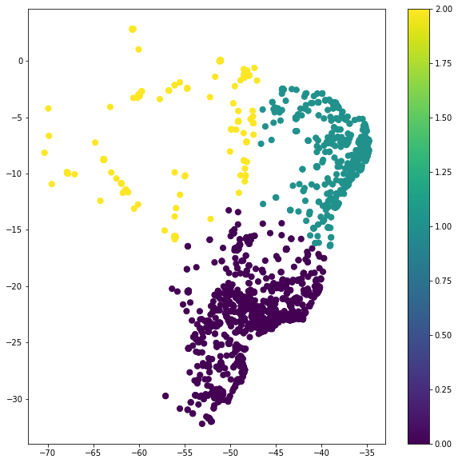

```python
fig = plt.figure(figsize=(10, 10))
ax = fig.add_subplot(111)
scatter = ax.scatter(restaurant['longitude'], restaurant['latitude'], c=preds, s=50)
plt.colorbar(scatter)
plt.show()
```

Perecebemos então a divisão dos restaurantes em três grupos de acordo com a latitude, longitude, o dia da semana e o turno que são visitados. Esses grupos poderiam ser melhor distribuídos caso existissem mais informações a respeito do perfil do usuário que esta visitando, por exemplo.

Como nãoo temos muito mais informações para clusterizar de forma melhor, latitude e longitude são as propriedades com maior peso no agrupamento.

Essa informação é importante, pois caso o varejista precise abrir um novo restaurante numa região, que fique ali proximo a interseccao dos três grupos, as propriedades dia da semana e turno vão dizer qual a melhor localização para ele abrir a loja, ou seja, em qual desses três clusters ele deve ser encaixado.

## Mais questionamentos

#### Qual o periodo do dia que as lojas recebem mais visitas?

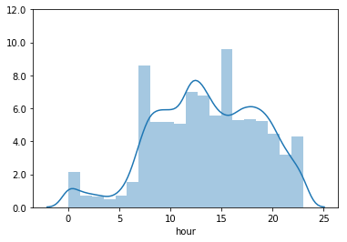

```python
fig = sns.distplot(data['hour'], bins=20)
plt.yticks(fig.get_yticks(), fig.get_yticks()*100)
plt.show()
```

Pelo histograma gerado a partir dos dados de hora o horario habitual de visitas se da no início da manhã, por volta das 7hs e no período da tarde, entre às 13hs e 16hs

#### Qual o dia da semana e a hora do dia que o varejista recebe mais visitas em suas lojas?

```python
visists_per_weekday = data.groupby(['day_of_week', 'hour'])['user'].count()
visists_per_weekday.loc[visists_per_weekday == visists_per_weekday.max()]
```

```
day_of_week  hour
Friday       12      401
Name: user, dtype: int64
```

O dia que o varejista recebe o maior numero de clientes em suas lojas é a sexta às 12hs.

#### Qual a categoria que mais recebe visitas?

```python
category_reg = data.groupby(['categoria'])['user'].count()
category_reg.loc[category_reg == category_reg.max()]
```

```
categoria
restaurant    5826
Name: user, dtype: int64
```

O tipo de loja que recebe mais visitas é o restaurante. É importante notar que isso está inteiramente ligado ao fato dos horários mais visitados serem no começo da manhã, meio do dia e fim da tarde.

#### Como traçar um perfil dos clientes?

Para responder essa pergunta podemos agrupar os dados de acordo com o usuário, as categorias que ele visitou e em quais dias da semana. Com mais informações sobre os clientes, por exemplo, idade, gastos na visista, poderiamos traçar um perfil mais explícito.

Dado que não temos todos esses dados, conseguimos visualizar se um cliente frequenta muito algum tipo de categoria e sugerir vouchers de fidelidade para ele de acordo com a categoria que ele mais frequenta.

```python
data.groupby(['user', 'categoria', 'day_of_week'])['user'].count()
```

```
user       categoria               day_of_week
User_1     gas_station             Thursday       1
           stadium                 Thursday       1
User_10    bar                     Friday         1
           doctor                  Monday         1
           restaurant              Tuesday        1
           store                   Saturday       1
User_100   grocery_or_supermarket  Sunday         1
           school                  Saturday       1
           store                   Monday         1
                                   Thursday       1
User_1000  painter                 Saturday       1
           school                  Friday         1
           shopping_mall           Friday         1
           storage                 Saturday       1
User_1001  shopping_mall           Wednesday      1
           store                   Thursday       1
User_1002  bakery                  Thursday       1
           doctor                  Tuesday        1
           electronics_store       Wednesday      1
           furniture_store         Monday         1
           hospital                Thursday       1
           lawyer                  Friday         1
           restaurant              Monday         1
                                   Tuesday        1
           storage                 Monday         1
User_1003  convenience_store       Sunday         1
           lawyer                  Friday         1
           moving_company          Wednesday      1
           restaurant              Saturday       1
User_1004  moving_company          Friday         1
                                                 ..
User_995   grocery_or_supermarket  Friday         1
           restaurant              Friday         1
                                   Monday         2
User_996   doctor                  Thursday       1
           gas_station             Sunday         1
                                   Tuesday        1
           locksmith               Tuesday        1
           pet_store               Monday         1
```

[output cut: 8 more lines]

```
           hospital                Monday         1
           locksmith               Friday         1
           parking                 Thursday       1
           place_of_worship        Monday         1
User_999   doctor                  Friday         1
                                   Thursday       1
           lawyer                  Saturday       1
           lodging                 Thursday       1
           restaurant              Monday         1
                                   Tuesday        1
           storage                 Sunday         1
           store                   Monday         1
                                   Saturday       1
                                   Sunday         1
Name: user, Length: 30124, dtype: int64
```

## Parte II

Resumo de como a análise de dados pode auxiliar no acompanhamento e direcionamento das seguintes áreas:

- RH
- Financeiro
- Imprensa/Marketing

### Análise de dados para o RH

Sabemos que a coleta e análise de dados é um processo constante e detalhado, e que através dessas análises conseguimos realizar diagnósticos a respeito da situação(saúde) da empresa. Sendo assim, para construir um bom planejamento estratégico esses dados devem ser bem coletados e analisados.

O RH é um setor muito cobrado por pontos como redução de custos na contratação, redução do índice de rotatividade dos funcionários e capacitação das equipes. Logo, fazer análises de dados pode resultar na criação mais assertiva de uma estratégia de contratação e retenção de colaboradores, aleḿ da capacitação e treinamento dos mesmo.

### Análise de dados para o setor financeiro

Os profissionais de controladoria e finanças devem focar na análise dos dados recebidos, transformando-os em informação, para ganhar produtividade e conseguir criar o canal que precisam para orientar outros departamentos em seus processos de tomada de decisão e assim alcançar os resultados esperados.

Através da análise de dados o setor financeiro consegue identificar os produtos/serviços que agregam mais valor, trazem rentabilidade e aumento da receita da empresa. Sendo assim, o setor pode sugerir novos investimentos, baseados na análise dos dados e conseguir entender, diariamente, a rentabilidade de cada cliente, produto ou processo para otimizar esses investimentos.

### Análise de dados para Imprensa/Marketing

Aproveitar a grande massa de informações geradas nas etapas de planejamento do marketing estratégico pode auxiliar na redução de perdas e aumento de faturamento. Dados históricos podem ajudar na continuação ou não de uma campanha de marketing de uma determinada região. Um trabalho de análise de dados para o setor de Imprensa/Marketing pode maximizar os ganhos e reduzir as perdas, baseado em previsões para novas campanhas que podem gerar maior vantagem competitiva no mercado sugerindo algo que seja relevante para o público-alvo da empresa.

Resumidamente, a análise de dados pode auxiliar em qualquer área da empresa, sendo utilizada para diminuir custos de aquisição de clientes, otimizar os investimentos, monitorar concorrentes, entre outras ações.